# Лабораторная работа №1

Установка и конфигурация ОС на виртуальную машину

Ришард Когенгар

Российский университет дружбы народов, Москва, Россия

18 января 2026

# Цель работы

## Основная цель

Приобрести практические навыки установки операционной системы на виртуальную машину и настройки минимально необходимых сервисов для дальнейшей работы.

# Ход выполнения работы

## Создание виртуальной машины в VirtualBox

- Среда виртуализации: **Oracle VirtualBox**
- Имя ВМ: **rishardkogengar**
- ISO-образ: **Rocky-10.1-x86_64-dvd1.iso**
- Тип ОС: **Linux → Red Hat → Red Hat (64-bit)**
- Автоустановка отключена (ручная настройка параметров)

[figure not shown]

Создание виртуальной машины и выбор ISO-образа

## Базовые параметры виртуальной машины

- ОЗУ: **4096 МБ**
- CPU: **4 виртуальных процессора**
- Видео: **VMSVGA**, видеопамять **128 МБ**
- Диск: **VDI 40 ГБ**, подключение к **SATA**

[figure not shown]

Основные параметры виртуальной машины

## Запуск установщика и выбор языка

- Запуск ВМ и загрузка установщика Rocky Linux с ISO
- Язык установщика: **English (United States)**

[figure not shown]

Выбор языка установки

## Сводка установки и выбор окружения

- Экран **Installation Summary**
- Базовая среда: **Server with GUI**
- Настроены: локализация, сеть, учётные записи
- Часовой пояс: **Europe/Moscow**

[figure not shown]

Сводка параметров установки

## Процесс установки и завершение

- Копирование файлов и конфигурация компонентов
- Успешное завершение установки
- Требуется перезагрузка

[figure not shown]

Завершение установки Rocky Linux

## Установка VirtualBox Guest Additions

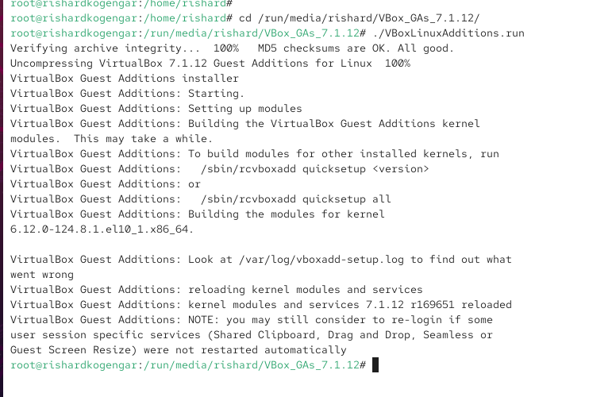

Установка VirtualBox Guest Additions

## Анализ загрузки системы (dmesg)

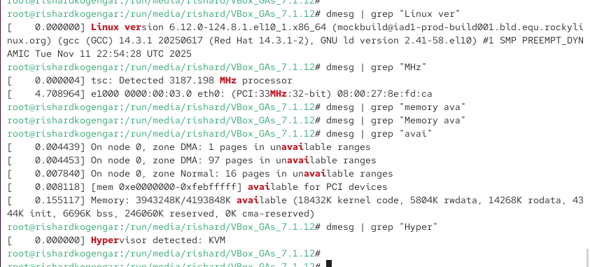

Анализ загрузки системы и монтирования файловых систем

## Монтирование файловых систем (mount)

- Получение сведений о монтировании: `mount`
- Просмотр корневого, системных и временных разделов

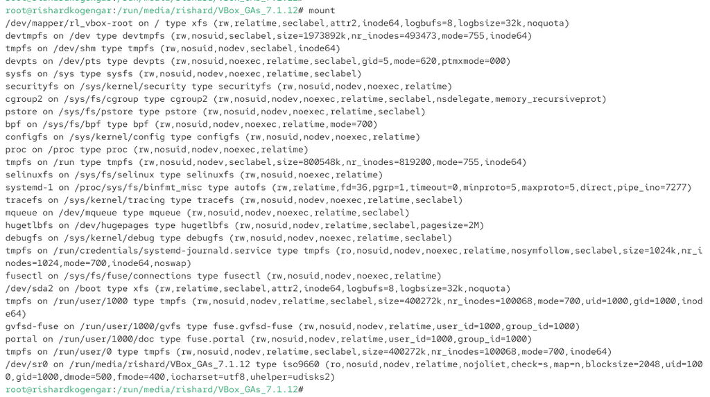

Анализ загрузки системы и монтирования файловых систем

# Итоги работы

## Вывод

- Rocky Linux **10.1** успешно установлена на ВМ в **Oracle VirtualBox**
- Выполнена базовая конфигурация ВМ и системы
- Установлены **Guest Additions**
- Проведён анализ загрузки, параметров оборудования и файловых систем  
  **Система готова к дальнейшей эксплуатации.**